# Dey Sarkar_Arnab_HW_03

## CMPINF 2100: Homework 03

## Assigned: Tuesday of Week 03 at 11:00PM

## DUE: Tuesday of Week 04 at 11:59PM

You will execute several important data analysis operations in this assignment. You will count using list methods and organize your results via iteration techniques into dictionaries. You will also practice splitting and summarizing data using NumPy arrays. This assignment therefore lets you practice important data organization techniques and data summary actions. We will use all of these operations later in the semester when we learn how to explore, summarize, and model data.

You may add as many code and markdown cells as you see fit to answer the questions.

### Collaborators

Type the names of other students you worked with here.

## Preliminaries

The first few problems are associated with the Pittsburgh Pirates, the local Major League Baseball (MLB) team in Pittsburgh, PA. The MLB consists of 30 baseball teams. A single game is between 2 teams, a Home team and an Away team. The two teams usually play 3 to 4 games in a row, before changing to different opponents. The consecutive games between the same two teams are referred to as a "series" in baseball nomenclature.

You will work with a list where each element provides the name of the team the Pirates played against. Specifically, seven series of games are created and assigned to the `opponents` object in the cell below. The object is created to be easy to visually confirm the number of games within each series against an opposing team. Note that the `\` character continues the line of code across multiple lines.

```python
opponents = 3 * ['Cardinals'] + 3 * ['Brewers'] \
+ 3 * ['Cubs'] + 4 * ['Twins'] \
+ 3 * ['Tigers'] + 3 * ['Cardinals'] + 3 * ['Reds']
```

The `opponents` object is printed for you below.

```python
print( opponents )
```

```
['Cardinals', 'Cardinals', 'Cardinals', 'Brewers', 'Brewers', 'Brewers', 'Cubs', 'Cubs', 'Cubs', 'Twins', 'Twins', 'Twins', 'Twins', 'Tigers', 'Tigers', 'Tigers', 'Cardinals', 'Cardinals', 'Cardinals', 'Reds', 'Reds', 'Reds']
```

## Problem 01

Let's begin by focusing on the `opponents` object itself.

### 1a) - QUESTION

Print the `opponents` object data type to the screen.

#### 1a) - SOLUTION

```python
type(opponents)
```

```
list
```

### 1b) - QUESTION

Each element in the `opponents` object corresponds to a game. How many games did the Pirates play over the seven series contained within the `opponents` object? Print you rresult to the screen.

#### 1b) - SOLUTION

```python
len(opponents)
```

```
22
```

### 1c) - QUESTION

Determine the **UNIQUE** or **DISTINCT** teams the Pirates played against within `opponents`. Assign the result to the `unique_teams` variable. Print the names of the unique teams to the screen.

#### 1c) - SOLUTION

```python
unique_teams=set(opponents)
print(unique_teams)
```

```
{'Cubs', 'Tigers', 'Cardinals', 'Brewers', 'Reds', 'Twins'}
```

### 1d) - QUESTION

What is the data type associated with the `unique_teams` object? As a hint, your `unique_teams` object must be a DIFFERENT data type from `opponents`.

What makes the `unique_teams` data type "special" or different from the `opponents` data type? Type your response by adding a Markdown cell below.

#### 1d) - SOLUTION

```python
type(unique_teams)
```

```
set
```

We have applied the set function on list which returns the set data type. opponents is list.

Set is unordered but list is ordered. Both are mutable but we can't access a particular element of a set. For the same reason we can not change a particular place holder in sets. Also slicing and indexing is not allowed in a set. List can have duplicate values but set can not.

### 1e) - QUESTION

Convert the `unique_teams` object to a list and assign the result to the `teams_list` object.

Print the `teams_list` object to the screen.

#### 1e) - SOLUTION

```python
team_list=list(unique_teams)
print(team_list)
```

```
['Cubs', 'Tigers', 'Cardinals', 'Brewers', 'Reds', 'Twins']
```

### 1f) - QUESTION

Sort the `teams_list` object and print the sorted list to the screen.

Is the ordering the same as what was displayed in the previous problem?

#### 1f) - SOLUTION

```python
team_list.sort()
print(team_list)
```

```
['Brewers', 'Cardinals', 'Cubs', 'Reds', 'Tigers', 'Twins']
```

The ordering is different.

## Problem 02

Now that you know the unique teams the Pirates played against, it is time to start counting!

### 2a) - QUESTION

Let's start by counting a single team. Count the number of times the Pirates played the Cardinals. Print the result to the screen.

*HINT*: You can count by hand to make sure your result is correct.

#### 2a) - SOLUTION

```python
opponents.count('Cardinals')
```

```
6
```

### 2b) - QUESTION

You counted the number of games against a single team in 2a). However, the Pirates played against more than just 1 team within the `opponents` object. As a reminder, all unique teams are contained with the `teams_list` object.

You must now count the number of games the Pirates played against each team in `teams_list`. You **must** assign the result to a list named `games_per_team_list`. You **must** add elements to the `games_per_team_list` list by using a for-loop and the `.append()` method.

Once completed, print the `games_per_team_list` object to the screen.

#### 2b) - SOLUTION

```python
games_per_team_list=[]
for a_team in team_list:
    s=opponents.count(a_team)
    games_per_team_list.append("%s %d" %(a_team, s))
print(games_per_team_list)
```

```
['Brewers 3', 'Cardinals 6', 'Cubs 3', 'Reds 3', 'Tigers 3', 'Twins 4']
```

```python
games_per_team_list=[]
for a_team in team_list:
    s=opponents.count(a_team)
    games_per_team_list.append((a_team, s))
print(games_per_team_list)
```

```
[('Brewers', 3), ('Cardinals', 6), ('Cubs', 3), ('Reds', 3), ('Tigers', 3), ('Twins', 4)]
```

```python
# On question 3, I realised that he wants
games_per_team_list=[]
for a_team in team_list:
    s=opponents.count(a_team)
    games_per_team_list.append(s)
print(games_per_team_list)
```

```
[3, 6, 3, 3, 3, 4]
```

### 2c) - QUESTION

There is nothing incorrect about using for-loops, but we learned about a more streamlined approach to iteratively applying operations. You must repeat counting operation but this time using a **list comprehension**. Assign the result to the `games_per_team_comp` object. Once completed, print your result to the screen.

#### 2c) - SOLUTION

```python
games_per_team_comp=["%s %d" %(a_team,opponents.count(a_team)) for a_team in team_list]
print(games_per_team_comp)
```

```
['Brewers 3', 'Cardinals 6', 'Cubs 3', 'Reds 3', 'Tigers 3', 'Twins 4']
```

```python
# On question 3, I realised that he wants
games_per_team_comp=[opponents.count(a_team) for a_team in team_list]
print(games_per_team_comp)
```

```
[3, 6, 3, 3, 3, 4]
```

### 2d) - QUESTION

Use a conditional test to confirm that `games_per_team_comp` and `games_per_team_list` contain the same values.

Print the result of the conditional test to the screen.

#### 2d) - SOLUTION

```python
games_per_team_comp==games_per_team_list
```

```
True
```

## Problem 03

You organized the counts for each team into a list. Great! But, do you know which value (Team) is associated with which count? Unfortunately, you have run into a limitation of the Python list! It can only store values. Lists cannot store any other contextual information about the values! It would be great if the counts **AND** the Team name associated with the count could be stored together! That's exactly what the Python dictionary allows us to do!

You will repeat the counting operation from the previous problem, but organize the results into a Dictionary.

### 3a) - QUESTION

However, before working with Dictionaries let's pause and consider the differences between the data types.

Describe a few differences between Python lists and Dictionaries in a Markdown cell below.

#### 3a) - SOLUTION

Add your Markdown cell below.

Lists are ordered by number and dictionary is ordered by keyargs. We can not give custom names to my list inputs but we can do that in dictionary.

### 3b) - QUESTION

Let's now count and organize the results within a Dictionary!

Create a Dictionary with ITEMS corresponds to the Team as the KEY and the count (number of games played against the Pirates) as the VALUE. You **must** fill the ITEMS in the Dictionary using a for-loop. You are allowed to use the `teams_list` and `games_per_team_list` (or `games_per_team_comp`) objects you created in the previous problems to help with this question.

Assign the result to the `games_per_team_dict` dictionary.

Print the `games_per_team_dict` object to the screen, once it has been created.

#### 3b) - SOLUTION

```python
games_per_team_dict={}
for a_team in team_list:
    games_per_team_dict[a_team]=opponents.count(a_team)

games_per_team_dict
```

```
{'Brewers': 3, 'Cardinals': 6, 'Cubs': 3, 'Reds': 3, 'Tigers': 3, 'Twins': 4}
```

### 3c) - QUESTION

The list comprehension provides a more streamlined way of populating values within lists. The **dictionary comprehension** gives a similar streamlined approach for storing results in Dictionaries! You must now use a dictionary comprehension to programmatically create the dictionary `games_per_team_dict_comp` which stores the count as the VALUE and the team as the KEY. You may use the `teams_list` and `games_per_team_list` to help with this question.

Print the `games_per_team_dict_comp` object to the screen,

*HINT*: The `zip()` function will help you here...

#### 3c) - SOLUTION

```python
key_values=team_list
values=games_per_team_list
games_per_team_dict_comp={a_key:a_value\
                for a_key, a_value in zip(key_values,values)}
```

```python
print(games_per_team_dict_comp)
```

```
{'Brewers': 3, 'Cardinals': 6, 'Cubs': 3, 'Reds': 3, 'Tigers': 3, 'Twins': 4}
```

```python
#Another way
games_per_team_comp1={a_key: opponents.count(a_key)\
    for a_key in key_values}
```

### 3d) - QUESTION

Use a conditional test to confirm that `games_per_team_dict` and `games_per_team_dict_comp` contain the same ITEMS.

Print the result of the conditional test to the screen.

#### 3d) - SOLUTION

```python
games_per_team_dict==games_per_team_dict_comp
```

```
True
```

## Problem 04

Counting is very important! We will return to counting in a few weeks. The remainder of the assignment introduces NumPy arrays.

### 4a) - QUESTION

Import the NumPy module as the common alias `np`.

#### 4a) - SOLUTION

```python
import numpy as np
```

### 4b) - QUESTION

Let's begin by creating and manipulating a NumPy 1D array.

Use the `np.arange()` function to create a 1D array of 20 elements starting from the value 0. Assign the result to the `my_1d_array` object. Print the **data type** of the `my_1d_array` to the screen.

#### 4b) - SOLUTION

```python
my_1d_array=np.arange(20)
print(type(my_1d_array))
```

```
<class 'numpy.ndarray'>
```

### 4c) - QUESTION

Use the appropriate attributes to print the number of dimensions, the size, and the shape associated with `my_1d_array`.

#### 4c) - SOLUTION

```python
print(my_1d_array.ndim)
print(my_1d_array.size)
print(my_1d_array.shape)
```

```
1
20
(20,)
```

### 4d) - QUESTION

Conditionally subset the `my_1d_array` and return all values where `my_1d_array` is greater than 10. Display the result to the screen.

#### 4d) - SOLUTION

```python
my_1d_array[my_1d_array>10]
```

```
array([11, 12, 13, 14, 15, 16, 17, 18, 19])
```

### 4e) - QUESTION

Let's now consider extending beyond the 1D array. The cell below defines a list of lists, `list_of_lists_a`.

```python
list_of_lists_a = [[0, 0, 0, 0, 0],
                  [1, 1, 1, 1, 1],
                  [2, 2, 2, 2, 2]]
```

You must convert this list of lists into a NumPy array and assign the result to the `array_from_list_a` object.

#### 4e) - SOLUTION

```python
array_from_list_a=np.array(list_of_lists_a)
array_from_list_a
```

```
array([[0, 0, 0, 0, 0],
       [1, 1, 1, 1, 1],
       [2, 2, 2, 2, 2]])
```

### 4f) - QUESTION

Use the appropriate attributes to print the number of dimensions, the size, and the shape associated with `array_from_list_a`.

#### 4f) - SOLUTION

```python
print(array_from_list_a.ndim)
print(array_from_list_a.size)
print(array_from_list_a.shape)
```

```
2
15
(3, 5)
```

### 4g) - QUESTION

What is the difference between the attributes associated with `my_1d_array` and those associated with `array_from_list_a`?

Type your response in a Markdown cell below.

#### 4g) - SOLUTION

We had the 2nd co ordinate in the tuple empty for 1D. 1D array is basically one dimensional array and array_from_list_a is two dimensional. In 1D size no =shape numeric value but in 2D, size=15=3*5=(no of rows)*(no of columns).

## Problem 05

Let's continue to practice manipulating NumPy arrays.

### 5a) - QUESTION

The cell below defines another list of lists, `list_of_lists_b`.

```python
list_of_lists_b = [[3, 3, 3, 3, 3],
                  [4, 4, 4, 4, 4]]
```

You must convert the `list_of_lists_b` object into a NumPy array and assign the result to the `array_from_list_b` object.

Display the SHAPE of the `array_from_list_b` object to the screen.

#### 5a) - SOLUTION

```python
array_from_list_b=np.array(list_of_lists_b)
array_from_list_b.shape
```

```
(2, 5)
```

### 5b) - QUESTION

You will now concatenate the `array_from_list_a` and `array_from_list_b` arrays. Concatenate or stack them VERTICALLY and assign the result to the `my_stacked_array`.

Would the number of dimensions of `my_stacked_array` be different from either of the arrays you combined to create it? Print the appropriate attribute to the screen to check your answer.

#### 5b) - SOLUTION

```python
my_stacked_array=np.vstack([array_from_list_a,array_from_list_b])
```

```python
print(my_stacked_array.ndim)
print(my_stacked_array.size)
print(my_stacked_array.shape)
```

```
2
25
(5, 5)
```

```python
my_stacked_array.ndim==array_from_list_a.ndim
```

```
True
```

```python
my_stacked_array.ndim==array_from_list_b.ndim
```

```
True
```

All the array a,b and stacked are of same dimension 2.

### 5c) - QUESTION

Slice the `my_stacked_array` object by selecting the first two columns and all rows EXCEPT the last row. Assign the result to the `my_subset_array` object. Print the `my_subset_array` object to the screen.

*NOTE*: Please use the default subset/slice approach for this question.

#### 5c) - SOLUTION

```python
my_stacked_array
```

```
array([[0, 0, 0, 0, 0],
       [1, 1, 1, 1, 1],
       [2, 2, 2, 2, 2],
       [3, 3, 3, 3, 3],
       [4, 4, 4, 4, 4]])
```

```python
my_subset_array= my_stacked_array[0:4, 0:2]
print(my_subset_array)
```

```
[[0 0]
 [1 1]
 [2 2]
 [3 3]]
```

### 5d) - QUESTION

Let's now modify the values in the smaller array.

Assign the ZEROTH row and ZEROTH column in `my_subset_array` to 99.

Assign the LAST row and ZEROTH column in `my_subset_array` to -99.

Assign the ZEROTH row and LAST column in `my_subset_array` to 9999.

Assign the LAST row and LAST column in `my_subset_array` to -9999.

Print the `my_subset_array` to the screen.

#### 5d) - SOLUTION

```python
my_subset_array[0,0]=99
#print(my_subset_array)
my_subset_array[-1,0]=-99
#print(my_subset_array)
my_subset_array[0,-1]=9999
#print(my_subset_array)
my_subset_array[-1,-1]=-9999
print(my_subset_array)
```

```
[[   99  9999]
 [    1     1]
 [    2     2]
 [  -99 -9999]]
```

### 5e) - QUESTION

Did your action in the last question change the `my_stacked_array` object?

Why or why not?

Print `my_stacked_array` to the screen to confirm you are correct.

#### 5e) - SOLUTION

```python
my_stacked_array
```

```
array([[   99,  9999,     0,     0,     0],
       [    1,     1,     1,     1,     1],
       [    2,     2,     2,     2,     2],
       [  -99, -9999,     3,     3,     3],
       [    4,     4,     4,     4,     4]])
```

Yes it changed as slicing has a side effect.

## Problem 06

You have created, concatenated, sliced, and manipulated NumPy arrays. It is now time to practice **summarizing** arrays!

You will continue to use the `my_stacked_array` object for this problem.

**IMPORTANT**: You **must** answer this question **AFTER** the previous question.

### 6a) - QUESTION

The `my_stacked_array` object has ROWS and COLUMNS. You will practice summarizing the **COLUMNS** first.

Use the appropriate NumPy method to calculate the **sample average** for each COLUMN in `my_stacked_array`.

You do not need to assign the result to a new object, simply print the result to the screen.

#### 6a) - SOLUTION

```python
my_stacked_array.mean(axis=0)
```

```
array([1.4, 1.4, 2. , 2. , 2. ])
```

### 6b) - QUESTION

Use the appropriate NumPy method to calculate the **sample standard deviation** for each COLUMN in `my_stacked_array`.

You do not need to assign the result to a new object, simply print the result to the screen.

*HINT*: You MUST use the unbiased estimate!

#### 6b) - SOLUTION

```python
my_stacked_array.std(axis=0,ddof=1)
```

```
array([7.00235675e+01, 7.07036090e+03, 1.58113883e+00, 1.58113883e+00,
       1.58113883e+00])
```

### 6c) - QUESTION

Let's now practice summarizing the **ROWS** within `my_stacked_array`.

Use the appropriate NumPy method to calculate the **sample average** for each ROW in `my_stacked_array`.

You do not need to assign the result to a new object, simply print the result to the screen.

#### 6c) - SOLUTION

```python
my_stacked_array.mean(axis=1)
```

```
array([ 2.0196e+03,  1.0000e+00,  2.0000e+00, -2.0178e+03,  4.0000e+00])
```

### 6d) - QUESTION

Use the appropriate NumPy method to calculate the **sample standard deviation** for each ROW in `my_stacked_array`.

You do not need to assign the result to a new object, simply print the result to the screen.

*HINT*: You MUST use the unbiased estimate!

#### 6d) - SOLUTION

```python
my_stacked_array.std(axis=1,ddof=1)
```

```
array([4460.82619029,    0.        ,    0.        , 4461.84504437,
          0.        ])
```

### 6e) - QUESTION

You summarized the NumPy array several different ways. First, summarizing the COLUMNS and then summarizing the ROWS.

How many values were displayed when you summarized the COLUMNS?

How many values were displayed when you summarized the ROWS?

Why are the number of summarized the same or different? Type your response in a Markdown cell below.

#### 6e) - SOLUTION

The no of summarized rows and columns are same as the stacked array has 5 roows and 5 columns.

## Problem 07

You performed a simulation in the previous assignment to estimate the standard error on the mean. The samples were generated assuming a Gaussian distribution with mean (location) equal to 100 and standard deviation (scale) equal to 25. You estimated the standard error using 5000 replications for multiple sample sizes.

You will perform the same kind of simulation again but this time using NumPy to generate the random numbers, organize the samples, and summarize the samples appropriately. The end of the lecture of material in Week 03 will help you with this portion of the assignment.

Your simulation must include the following:

- Initialize the NumPy random number generator with the seed equal to 2100
- Generate samples using a Gaussian random number generator with mean 100 and standard deviation 25
- Generate 5000 replications for each sample size and organize the NumPy array 2D array
- The replications must correspond to the COLUMNS while the sample size must correspond to the ROWS of the 2D array
- Summarize samples by calculating the sample average for each replication using the appropriate NumPy method
- Calculate the SEM by calculating the standard deviation of the averages using the appropriate NumPy method
  - Your standard deviation MUST be unbiased!!!
- You must iterate over various sample sizes using a list comprehension
  - The sample sizes you must use are provided in a list below
- You must visualize the SEM with respect to the sample size on a plot
  - The plot is started for you since we have not discussed creating plots yet

The specific sample sizes you must use are provided below:

```python
sample_size_use = [5, 10, 20, 40, 80, 160, 320, 640, 1280, 2560, 5120, 10240]
```

#### 7a) - SOLUTION

Add as many cells as you feel are necessary below to complete the simulation.

*HINT*: Do NOT forget to set the random seed!

```python
rg=np.random.default_rng(2100)
sem_vs_samplesize=[rg.normal(100,25,(ns,5000))\
    .mean(axis=0).std(ddof=1) \
    for ns in sample_size_use]
```

The plot is started for you below. You only need to complete 1 line!

```python
import matplotlib.pyplot as plt
```

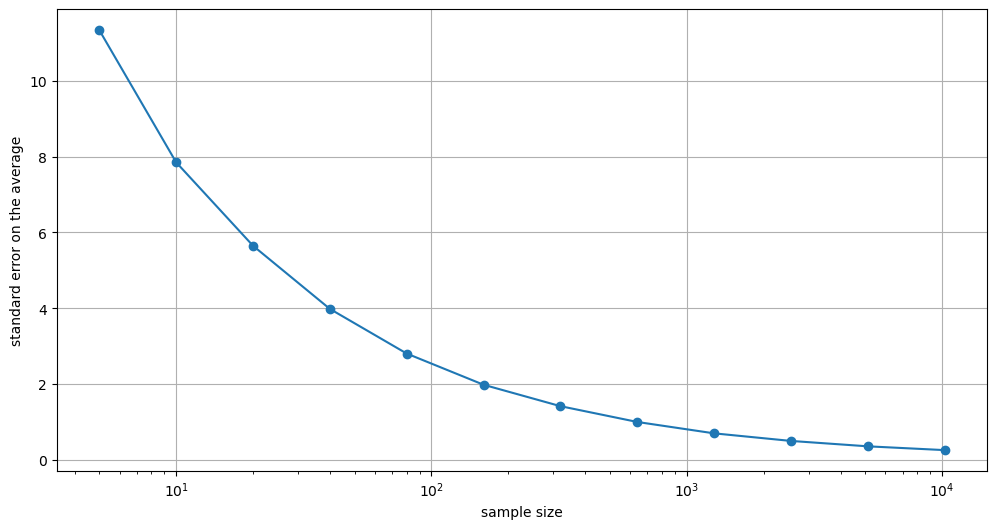

```python
fig, ax = plt.subplots(figsize=(12, 6))

ax.plot(sample_size_use,sem_vs_samplesize,'-o')
ax.set_xscale('log')
ax.set_xlabel('sample size')
ax.set_ylabel('standard error on the average')
ax.grid(True)
plt.show()
```

## Problem 08

You will complete a data analysis project in the second half of the semester. You looked through several of the potential projects in the last assignment. Several more projects have been added to Canvas.

Please look through the material associated with the new of projects on Canvas. Do any seem interesting to you? If so, what aspect of the project did you find interesting? Do you prefer one of the projects from the previous set of projects?

#### 8) - SOLUTION

Please type your response below.

I liked the project related to battery and Dr Yurko said that the corrosion model is similar to neuroscience models so I would be looking for that.